# Machine learning Project : EasyVisa

## Data Preprocessing

### Data Preparation for Modeling

#### Outlier Detection

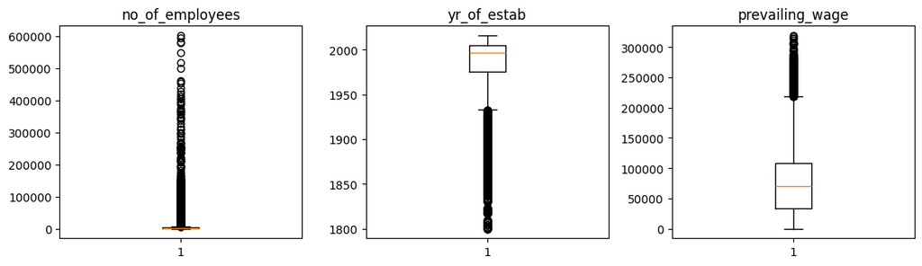

```python
# outlier detection using boxplot

# Selects numerical columns from the DataFrame `data` using `select_dtypes(include=np.number)` and converts the column names to a list.
numeric_columns = data.select_dtypes(include=np.number).columns.tolist()
# Creates a new figure and a set of subplots with a specified figure size.
plt.figure(figsize=(15, 12))
# Loops through the list of numerical column names and their index.
for i, variable in enumerate(numeric_columns): #Iterate through each column
    # Creates a subplot in the current figure. The layout is 4 rows by 4 columns, and the current subplot is at position i + 1.
    plt.subplot(4, 4, i + 1)
    # Generates a box plot for the current numerical variable. `whis=1.5` sets the length of the whiskers.
    plt.boxplot(data[variable], whis=1.5) # plot the boxplot
    # Adjusts subplot parameters for a tight layout.
    plt.tight_layout()
    # Sets the title of the current subplot to the name of the variable.
    plt.title(variable)
# Displays the plots.
plt.show()
```

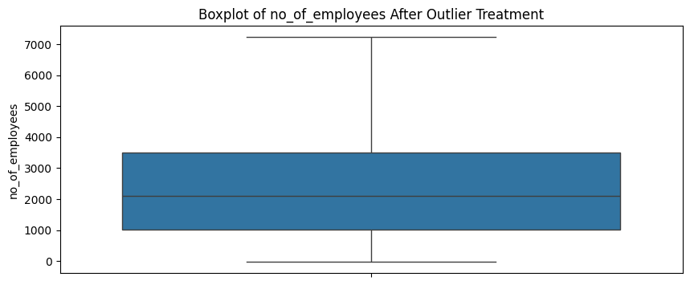

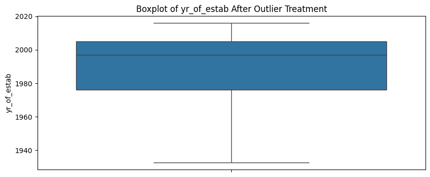

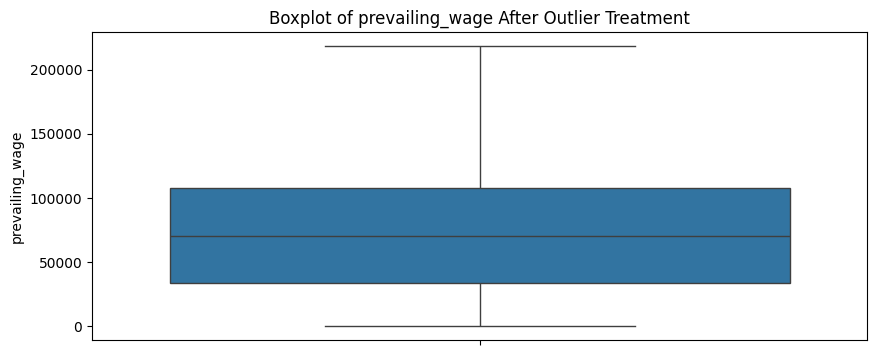

```python
# Outlier Treatment using Winsorization for numerical columns
for col in numerical_columns:
  # Calculate IQR
  Q1 = Visa[col].quantile(0.25)
  Q3 = Visa[col].quantile(0.75)
  IQR = Q3 - Q1

  # Define lower and upper bounds for outliers using the IQR method
  lower_bound = Q1 - 1.5 * IQR
  upper_bound = Q3 + 1.5 * IQR

  # Apply winsorization: cap values below the lower bound and above the upper bound
  Visa[col] = np.where(Visa[col] < lower_bound, lower_bound, Visa[col])
  Visa[col] = np.where(Visa[col] > upper_bound, upper_bound, Visa[col])

# Verify the outlier treatment by plotting boxplots again
for col in numerical_columns:
  plt.figure(figsize=(10, 4))
  sns.boxplot(data=Visa, y=col)
  plt.title(f'Boxplot of {col} After Outlier Treatment')
  plt.show()
```

Observations

1.The Winsorization technique is used as the outlier treatment method. It calculates the Interquartile Range (IQR) for each numerical column (`no_of_employees`, `yr_of_estab`, `prevailing_wage`).

**Why Outlier Treatment is Needed:**

1. **Impact on Model Performance:** Outliers can disproportionately influence the model's parameters, leading to biased results and reduced predictive performance on unseen data. For instance, a few extremely high `prevailing_wage` values could skew a model trying to learn the typical relationship between wage and visa status.
2. **Distorted Statistical Analysis:** Outliers can significantly inflate measures of central tendency like the mean and measures of dispersion like the standard deviation and variance. This can give a misleading picture of the typical data distribution and relationships between variables during the Exploratory Data Analysis (EDA) phase.
3. **Violation of Model Assumptions:** Some models assume that the data is normally distributed or that there are no extreme values. Outliers can violate these assumptions, making the model results less reliable or the model training process unstable.
4. **Improved Robustness:** By treating outliers, the model becomes more robust to variations in the data and is less likely to be thrown off by unusual or erroneous data points.
5. **Better Data Representation:** In some cases, outliers might represent data entry errors or rare events that are not representative of the overall population the model needs to generalize to. Treating them helps the model focus on the more typical patterns in the data.

In the context of the EasyVisa project, where `no_of_employees`, `yr_of_estab`, and `prevailing_wage` showed significant outliers, addressing these extremes is crucial to prevent them from negatively impacting the classification model's ability to accurately predict visa approval status. Winsorization was applied to mitigate the influence of these extreme values while preserving the overall sample size, which is often preferred over simply removing the data points.

### Creating trainining and test split

```python
X = Visa.drop(["case_status"], axis=1)
y = Visa["case_status"].apply(lambda x: 1 if x == "Certified" else 0)
```

```python
# Splitting data into training, validation and test set:
# first we split data into 2 parts, say temporary and test

X_temp, X_test, y_temp, y_test = train_test_split(
    X, y, test_size=0.2, random_state=1, stratify=y
)

# then we split the temporary set into train and validation

X_train, X_val, y_train, y_val = train_test_split(
    X_temp, y_temp, test_size=0.25, random_state=1, stratify=y_temp
)
print(X_train.shape, X_val.shape, X_test.shape)
```

```
(15288, 10) (5096, 10) (5096, 10)
```

```python
print("Number of rows in train data =", X_train.shape[0])
print("Number of rows in validation data =", X_val.shape[0])
print("Number of rows in test data =", X_test.shape[0])
```

```
Number of rows in train data = 15288
Number of rows in validation data = 5096
Number of rows in test data = 5096
```

### Creating Dummy Variables

```python
X_train = pd.get_dummies(X_train, drop_first=True)
X_train = X_train.astype(float)

X_val = pd.get_dummies(X_val, drop_first=True)
X_val = X_val.astype(float)

X_test = pd.get_dummies(X_test, drop_first=True)
X_test = X_test.astype(float)

print(X_train.shape, X_val.shape, X_test.shape)
```

```
(15288, 21) (5096, 21) (5096, 21)
```

After encoding there are 21 columns.

# Model Building

## Model evaluation criterion

**Model can make wrong predictions as**

- 1. Predicting that a visa application will be certified when it is actually denied (False Positive) - This could lead to a foreign worker entering the country who doesn't meet the requirements, potentially impacting the US labor market negatively and causing administrative issues.
- 1. Predicting that a visa application will be denied when it should have been certified (False Negative) - This could mean denying a qualified and needed foreign worker, resulting in a loss of potential talent for US companies and potentially hindering economic growth.

**Which case is more important?**

Both cases have negative consequences, but in the context of EasyVisa assisting OFLC to efficiently process increasing applications, prioritizing the identification of applications that are *likely to be certified* to streamline that process seems crucial. Missing a potential certified application (False Negative) directly hinders the objective of accelerating approvals for qualified candidates.

**How to reduce this loss i.e need to reduce False Negatives?**

To reduce False Negatives, we need to prioritize **Recall**. Maximizing Recall means minimizing the number of actual certified cases that are predicted as denied. By having a high Recall, the model will be better at identifying potentially certifiable applications, which aligns with the goal of accelerating the approval process for eligible candidates.

**Let's define a function to output different metrics (including recall) on the train and test set and a function to show confusion matrix so that we do not have to use the same code repetitively while evaluating models.**

```python
# defining a function to compute different metrics to check performance of a classification model built using sklearn
def model_performance_classification_sklearn(model, predictors, target):
    """
    Function to compute different metrics to check classification model performance

    model: classifier
    predictors: independent variables
    target: dependent variable
    """

    # predicting using the independent variables
    pred = model.predict(predictors)

    acc = accuracy_score(target, pred)  # to compute Accuracy
    recall = recall_score(target, pred)  # to compute Recall
    precision = precision_score(target, pred)  # to compute Precision
    f1 = f1_score(target, pred)  # to compute F1-score

    # creating a dataframe of metrics
    df_perf = pd.DataFrame(
        {"Accuracy": acc, "Recall": recall, "Precision": precision, "F1": f1,},
        index=[0],
    )

    return df_perf
```

```python
def confusion_matrix_sklearn(model, predictors, target):
    """
    To plot the confusion_matrix with percentages

    model: classifier
    predictors: independent variables
    target: dependent variable
    """
    y_pred = model.predict(predictors)
    cm = confusion_matrix(target, y_pred)
    labels = np.asarray(
        [
            ["{0:0.0f}".format(item) + "\n{0:.2%}".format(item / cm.flatten().sum())]
            for item in cm.flatten()
        ]
    ).reshape(2, 2)

    plt.figure(figsize=(6, 4))
    sns.heatmap(cm, annot=labels, fmt="")
    plt.ylabel("True label")
    plt.xlabel("Predicted label")
```